# Aderência dos deputados em votações de Meio Ambiente

### Resumo

Analisamos quais deputados federais mais/menos seguem as orientações do Governo nas votações nominais em plenário da Câmara das proposições relacionadas ao Meio Ambiente. Usamos as votações que aconteceram em 2019.

### O que é aderência

Aderência é uma faceta da atuação dos Deputados Federais na câmara em votações. Um deputado é aderente ao Governo quando segue as orientações do Governo em votações nominais.

Para cada votação de cada deputado, identificamos se ele seguiu a orientação do Governo ou não. Em seguida, calculamos o grau de aderência como a proporção das votações em que ele seguiu a orientação do Governo. Quando o Governo não apresentou orientação em uma votação, essa votação não é considerada.

Existem 3 proposições que possuem votações em plenário cujo tema é classificado como **Meio Ambiente**.

- A **MPV 867/2018** que prorroga o prazo para adesão de produtores rurais ao Programa de Regularização Ambiental.
- A **PL 2787/2019** que tipifica o crime de ecocídio e a conduta delitiva do responsável por desastre relativo a rompimento de barragem.
- A **PL 2788/2019** que institui a Política Nacional de Direitos das Populações Atingidas por Barragens, e dá outras providências. Ao total temos 26 votações em plenário.

Nesta análise, *consideramos apenas deputados que participaram em pelo menos 10 com orientações do Governo, e apenas deputados de partidos com ao menos 5 membros na câmara*.

## Aderência ao Governo

### Quem tem menos aderência?

Abaixo apresentamos a lista dos 20 deputadas e deputados que menos seguiram a orientação do Governo para as votações relacionadas ao Meio Ambiente.

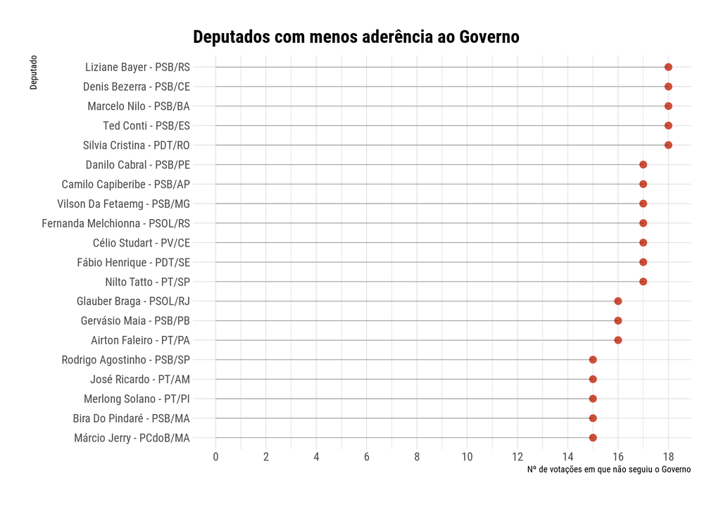

Todos estes deputados possuem uma aderência de 0% ao governo e estão ordenados pelo número de votações em que não seguiu a orientação do governo.

Existem 62 deputados que possuem 0% de aderência ao governo. Você pode conferir a lista no fim deste relatório.

### Mais detalhes sobre quem não adere

Para saber mais detalhes sobre o comportamento destes deputados nas 26 votações nominais acompanhe o gráfico abaixo.

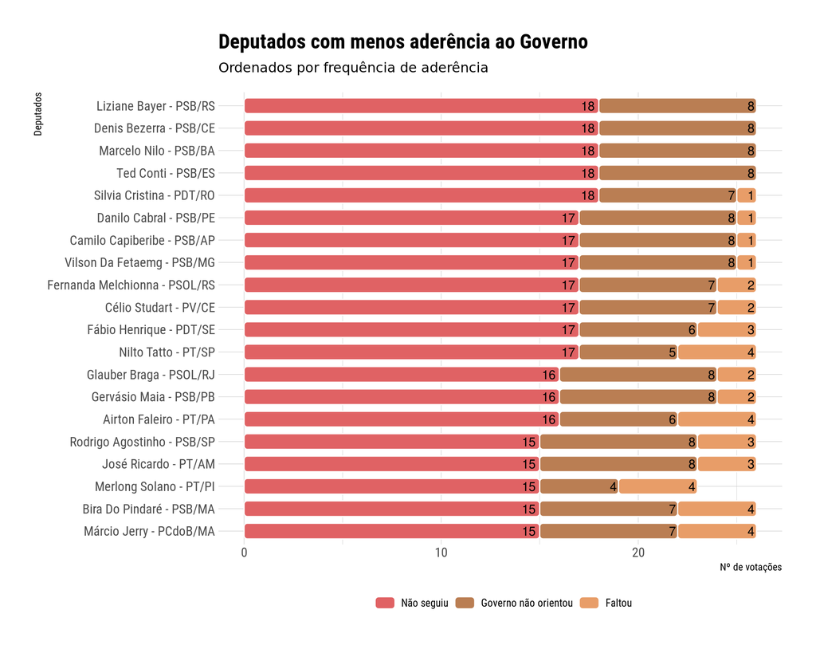

### Quem tem mais aderência?

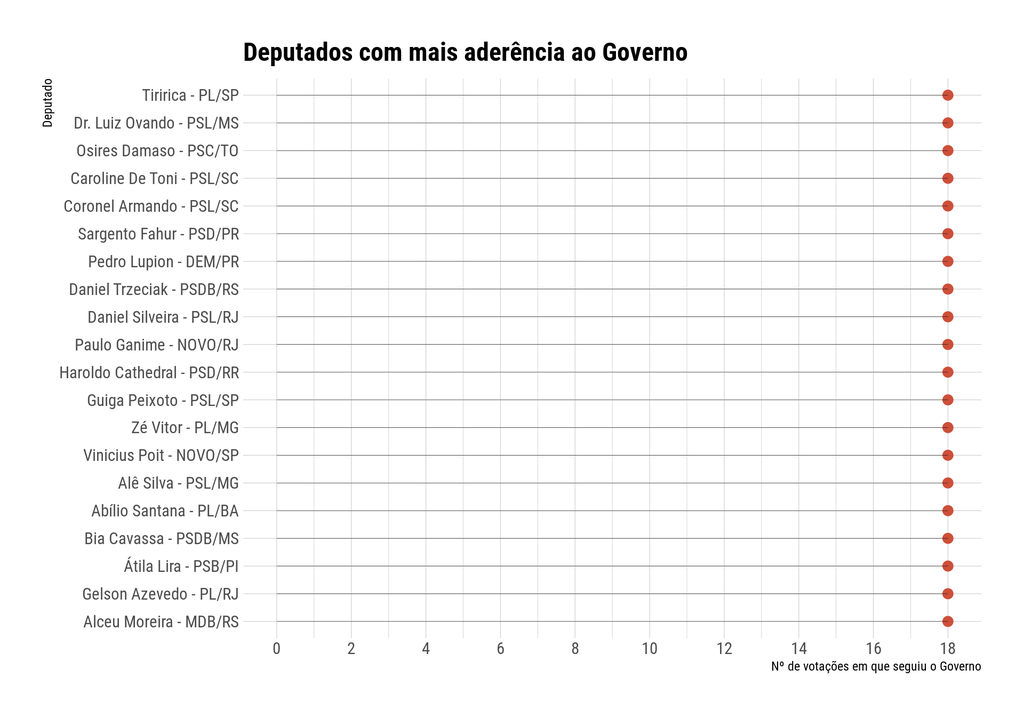

Todos estes deputados possuem uma aderência de 100% ao governo nas votações de Meio Ambiente. Existem 239 com aderência de 100% ao governo neste tema.

[figure not shown]

### Aderência nos partidos

Agora estamos interessados em analisar como os partidos e seus componentes seguem a orientação do Governo ou não para o tema de Meio Ambiente.

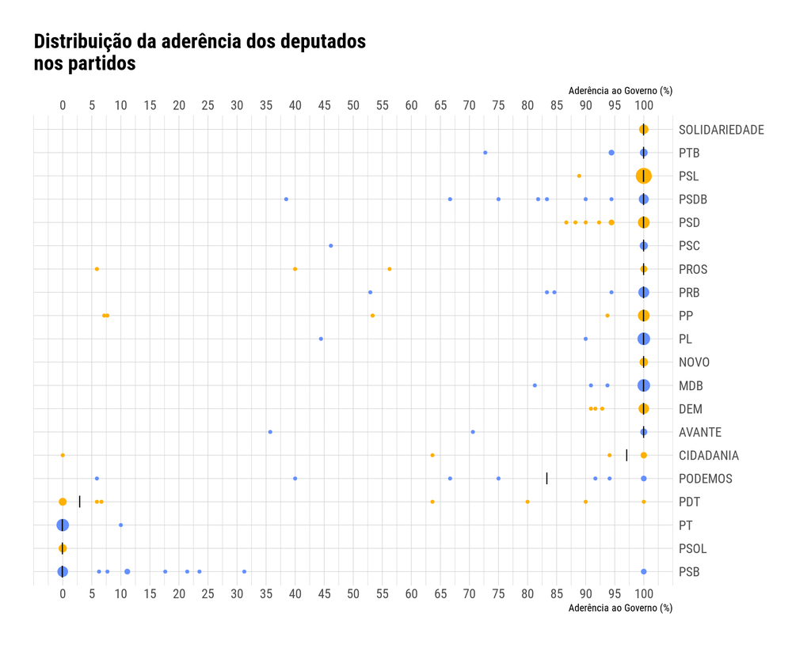

A marca “|” representa a mediana no gráfico. A mediana também é o critério de ordenação dos partidos. A maioria dos partidos aderem em 100% de mediana

Pela visualização é possível perceber que existem claramente partidos que divergem da orientação do governo quando consideramos a mediana das aderências de seus membros. Em outras palavras, deputados do PT, PSOL e PDT e PSB pouco ou nunca aderem a orientação do Governo para as votações de Meio Ambiente. No entanto, existem outliers para esse grupo, como alguns deputados do PDT que possuem aderência superior a 60% ao Governo e dois deputados do PSB com aderência de 100% ao Governo (Átila Lira - PSB/PI e Rodrigo Coelho - PSB/SC).

### Aderência nas Comissões

Em seguida, iremos analisar como os Deputados estão distribuídos nas comissões considerando suas aderências ao Governo em votações nominais de plenário. Foram consideradas Comissões Permanentes da Câmara e foram incluídos deputados titulares e suplentes.

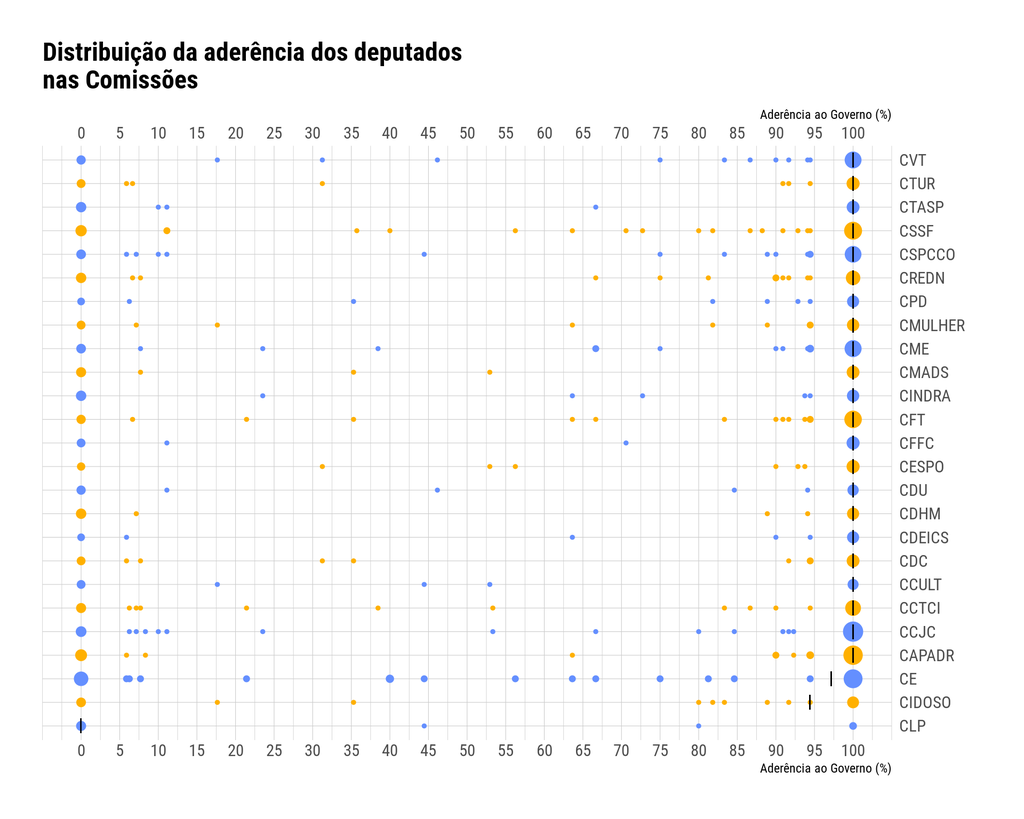

É possível perceber uma polarização em praticamente todas as comissões, contudo, a marca “|” que indica a mediana mostra que pelo menos 50% dos deputados na maioria das comissões é aderente ao Governo.

### Quantos deputados são aderentes ao Governo em Meio Ambiente

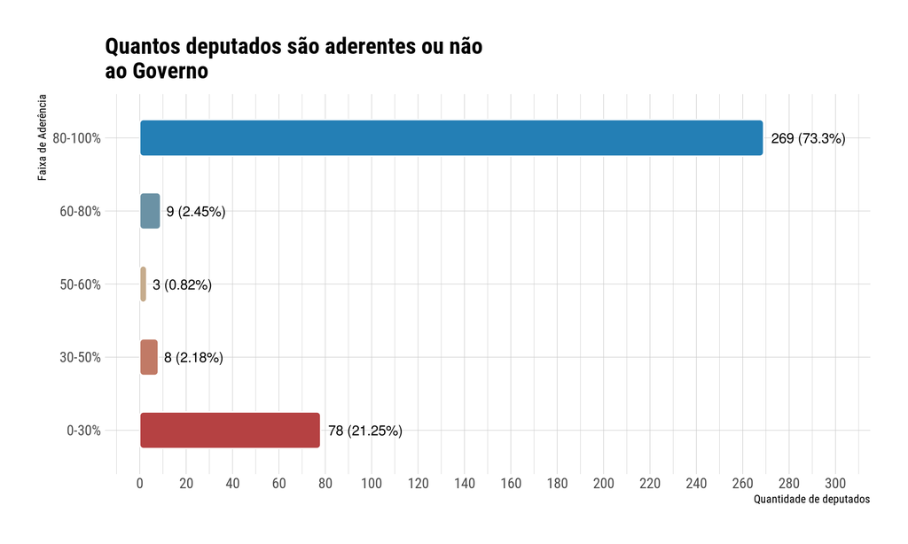

A contagem reafirma a presença de mais deputados aderentes ao governo do que aderentes. Os deputados foram divididos em 5 grupos considerando sua aderência ao governo. Pela visualização é possível concluir que 78 deputados estão na faixa de aderência entre 0-30% ao Governo, ou seja, não são aderentes. Estes 78 deputados correspondem a 21.25% (valor entre parênteses na visualização) do total de deputados (367) cuja aderência foi calculada.

Ao compararmos a proporção de deputados não aderentes ao Meio Ambiente com o diagnóstico que faz parte das atividades da 1ª fase do projeto #RADAR Clima & Sustentabilidade, do Instituto Democracia e Sustentabilidade (IDS) em parceria com o Congresso em Foco apresentado [aqui](https://congressoemfoco.uol.com.br/opiniao/colunas/o-desmonte-ambiental-na-camara/) por André Lima percebemos que o valor se aproxima. Detectamos que 23.43% (21.25% + 2.18%) dos deputados tem aderência considerada baixa com relação ao Governo, o que indica, segundo outros artigos do próprio André, um alinhamento com as posições favoráveis ao Meio Ambiente.

É importante lembrar que a quantidade de deputados analisada foi diferente pois para o cálculo da aderência não consideramos os deputados de partidos com menos de 5 membros e também deputados que tiveram menos de 10 votações nas quais o governo deu orientação.

Abaixo apresentamos uma tabela pesquisável com os dados de todos os deputados que participaram de votações no ano de 2019.

| id | Nome | Partido | Aderência | Seguiu | Não Seguiu | Faltou | Governo liberou |
| --- | --- | --- | --- | --- | --- | --- | --- |
| 204405 | Liziane Bayer - PSB/RS | PSB | 0 | 0 | 18 | 0 | 8 |
| 204542 | Denis Bezerra - PSB/CE | PSB | 0 | 0 | 18 | 0 | 8 |
| 204558 | Marcelo Nilo - PSB/BA | PSB | 0 | 0 | 18 | 0 | 8 |
| 206231 | Ted Conti - PSB/ES | PSB | 0 | 0 | 18 | 0 | 8 |
| 204360 | Silvia Cristina - PDT/RO | PDT | 0 | 0 | 18 | 1 | 7 |
| 160528 | Danilo Cabral - PSB/PE | PSB | 0 | 0 | 17 | 1 | 8 |
| 204352 | Camilo Capiberibe - PSB/AP | PSB | 0 | 0 | 17 | 1 | 8 |
| 204483 | Vilson Da Fetaemg - PSB/MG | PSB | 0 | 0 | 17 | 1 | 8 |
| 204407 | Fernanda Melchionna - PSOL/RS | PSOL | 0 | 0 | 17 | 2 | 7 |
| 204488 | Célio Studart - PV/CE | PV | 0 | 0 | 17 | 2 | 7 |

[output cut: 357 more lines]